# Homework 8 - BSTA 522

Matthew Hoctor

2/22/2022

# Part B:

Read 8d (report up to 5 bullet points, if you read this paper before, read 8d7 and 8d8 under the 8d CommentsRejoinder folder.)

- “Twentieth century” statistical methods can be contrasted to “twentyfirst century” methods in several important ways; while both allow for prediction of new observations, the former allows for attribution of significance of predictors, whereas the latter does not; the former tends to operate on small to medium datasets, whereas the latter is designed for very large datasets; and lastly these methods differ in assumptions, philosophy, and goals.
- Traditional ‘twentieth century’ methods can be thought of as being ‘surface plus noise’ models, in which regression coefficients describe a regression surface, and the error from that surface is thought of as noise; this is in contrast to the ‘pure prediction’ methods of the twentyfirst century, which don’t share a common model conceptualization (such as a regression surface), but provide different methods for prediction. Tree methods, forest methods, neural networks are briefly described as examples of these methods.
- The training-set/testing-set paradigm, in which a portion of the dataset is preserved (in the testing set) for estimation of the model’s ability to predict future observations, is described as an important aspect of the twentyfirst century approach. Concept drift, in which the phenomenon or dynamic being measured drifts slowly over time, is described as being a downside to this approach. The famous example given is that of the google flu predictions, which fell prey to this phenomenon because of fundamental differences in the dynamics of flu spread in different yearly flu seasons.
- The ‘smooth-world paradigm’ is described as another main difference between sets of methods. Earlier methods have smooth transitions between predictions, as in Newtonian physics, but latter methods have multiple discontinuities. Similarly earlier methods are contrasted to twentyfirst methods in that the former is more appropriate for long-form data, wheras the latter is more appropriate for ‘wide data’.
- The article is summarized in table 5 in which six qualities are contrasted and tabulated.

# Part C:

Note that msvmpath can be installed from the wk08folder. You may need to install svmpath from CRAN online, first. Use the tar.gz file. (packages -> install from a local file). Do not de-compress the file and use the file as it is to install.

- Import train.csv and test.csv in the wk08 folder and summarize them. (You can use read.csv(‘filename’) to import) and produce summary outputs and a scatter plot of x1 & x2 with y as color and/or point type.
  - Col 1: y (1, 2, 3 – 3 classes).
  - Col 2~3: two predictors
  - After import, you may need to set col 1 as a factor.
- Fit a classification tree (rpart using xerror to the train) and make predictions for the test.
- Fit a random forest to the train data and make predictions for the test. (choose an appropriate ntree).
- Fit a boosted tree to the train and make predictions for the test. (in gbm, use cv.folds=5 and make predictions with best.iter.)
- Fit svm with radial kernel (default) to the train and make predictions for test. (try a few cost values).
- Fit msvmpath with radial kernel to the train and make predictions for test. (kernel.function = radial.kernel) Report confusion matrices from the fitted models and discuss the results.

## Data Import & Preliminary Analysis

```r
#Read the .csv files
test <- read.csv("test.csv")
train <- read.csv("train.csv")

#Convert y-variable to a factor:
test$y <- as.factor(test$y)
train$y <- as.factor(train$y)

#Longform datasets:
test_long <- melt(test, value.name = "value")
train_long <- melt(train, value.name = "value")
#Geta little peak at the data:
head(test)
```

```
##   y       x1         x2
## 1 1 2.497808 -0.4470622
## 2 1 3.131531 -1.7385979
## 3 1 2.921083  0.1788648
## 4 1 3.886785  1.8974657
## 5 1 3.116971 -2.2719255
## 6 1 3.318630  0.9804641
```

```r
head(train)
```

```
##   y       x1          x2
## 1 1 3.934567  1.07946198
## 2 1 2.949385  0.08905254
## 3 1 1.353432 -1.20267377
## 4 1 3.836745  0.60938213
## 5 1 1.818880  0.29046674
## 6 1 2.867891  0.06526527
```

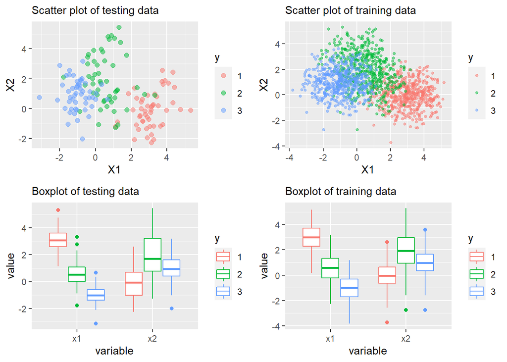

```r
p1 <- test %>%
  ggplot(aes(x1, x2, color=y)) +
  geom_point(alpha=0.5, size=2) +
  labs(y="X2", x="X1", subtitle="Scatter plot of testing data")

p2 <- train %>%
  ggplot(aes(x1, x2, color=y)) +
  geom_point(alpha=0.5, size=1) +
  labs(y="X2", x="X1", subtitle="Scatter plot of training data")

p3 <- test_long %>%
  ggplot(aes(x = variable, y = value, color = y)) +
  geom_boxplot() +
  labs(subtitle = "Boxplot of testing data")

p4 <- train_long %>%
  ggplot(aes(x = variable, y = value, color = y)) +
  geom_boxplot() +
  labs(subtitle = "Boxplot of training data")

grid.arrange(p1, p2, p3, p4, ncol = 2)
```

As we can see from the plots above, pairs of x-values tend to cluster based on y-value, and testing and training data have similar mean values for the same y-value.

## Classification Tree

```r
#Train the model
train.rpart0 <- rpart(y ~ ., data = train)

#display the tree:
train.rpart0
```

```
## n= 1500
##
## node), split, n, loss, yval, (yprob)
##       * denotes terminal node
##
##  1) root 1500 1000 1 (0.333333333 0.333333333 0.333333333)
##    2) x1>=1.484395 561   90 1 (0.839572193 0.160427807 0.000000000)
##      4) x1>=2.277803 399   21 1 (0.947368421 0.052631579 0.000000000) *
##      5) x1< 2.277803 162   69 1 (0.574074074 0.425925926 0.000000000)
##       10) x2< 1.170365 115   30 1 (0.739130435 0.260869565 0.000000000) *
##       11) x2>=1.170365 47    8 2 (0.170212766 0.829787234 0.000000000) *
##    3) x1< 1.484395 939  439 3 (0.030883919 0.436634718 0.532481363)
##      6) x1>=-0.2473127 430  141 2 (0.067441860 0.672093023 0.260465116)
##       12) x2>=1.626133 192   25 2 (0.010416667 0.869791667 0.119791667) *
##       13) x2< 1.626133 238  116 2 (0.113445378 0.512605042 0.373949580)
##         26) x1>=0.5965917 115   39 2 (0.226086957 0.660869565 0.113043478) *
##         27) x1< 0.5965917 123   47 3 (0.008130081 0.373983740 0.617886179) *
##      7) x1< -0.2473127 509  121 3 (0.000000000 0.237721022 0.762278978)
##       14) x2>=2.702423 75   19 2 (0.000000000 0.746666667 0.253333333) *
##       15) x2< 2.702423 434   65 3 (0.000000000 0.149769585 0.850230415) *
```

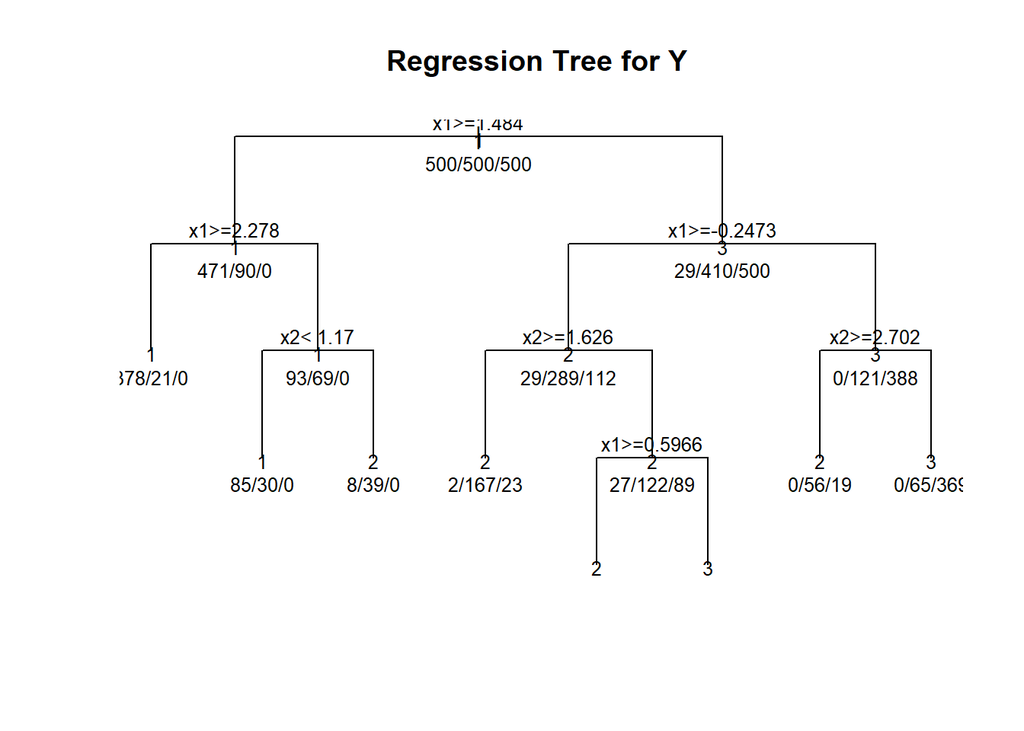

```r
#Plot the tree:
plot(train.rpart0, uniform=TRUE, main="Regression Tree for Y ")
text(train.rpart0, use.n=TRUE, all=TRUE, cex=.8)
```

```r
pred.test.rpart0 <- predict(train.rpart0,
                          newdata = test,
                          type = "class")
confusionMatrix(pred.test.rpart0, test$y)
```

```
## Confusion Matrix and Statistics
##
##           Reference
## Prediction  1  2  3
##          1 47  4  0
##          2  3 35  3
##          3  0 11 47
##
## Overall Statistics
##
##                Accuracy : 0.86
##                  95% CI : (0.794, 0.9112)
##     No Information Rate : 0.3333
##     P-Value [Acc > NIR] : < 2.2e-16
##
##                   Kappa : 0.79
##
##  Mcnemar's Test P-Value : NA
##
## Statistics by Class:
##
##                      Class: 1 Class: 2 Class: 3
## Sensitivity            0.9400   0.7000   0.9400
## Specificity            0.9600   0.9400   0.8900
## Pos Pred Value         0.9216   0.8537   0.8103
## Neg Pred Value         0.9697   0.8624   0.9674
## Prevalence             0.3333   0.3333   0.3333
## Detection Rate         0.3133   0.2333   0.3133
## Detection Prevalence   0.3400   0.2733   0.3867
## Balanced Accuracy      0.9500   0.8200   0.9150
```

## Random Forest

```r
#set seed for reproducibility:
set.seed(1237)
# Create Random forest
train.randomForest0 <- randomForest(y ~ .,
                                    data = train,
                                    ntree = 100,
                                    importance = TRUE)
print(train.randomForest0 )       #view results
```

```
##
## Call:
##  randomForest(formula = y ~ ., data = train, ntree = 100, importance = TRUE)
##                Type of random forest: classification
##                      Number of trees: 100
## No. of variables tried at each split: 1
##
##         OOB estimate of  error rate: 22.4%
## Confusion matrix:
##     1   2   3 class.error
## 1 443  56   1       0.114
## 2  66 320 114       0.360
## 3   1  98 401       0.198
```

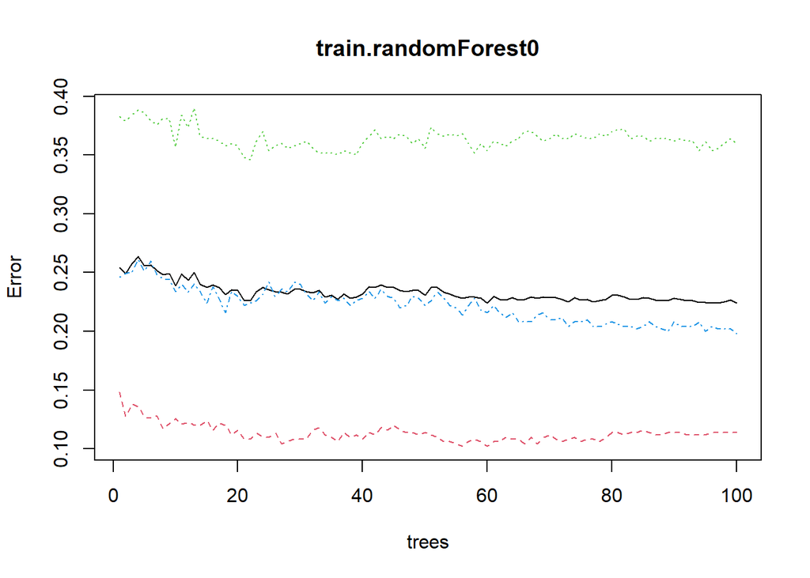

```r
plot(train.randomForest0 )        #black overall OOB error and each line for each class' error (ie 1-this class recall)
```

```r
importance(train.randomForest0 )  #importance of each predictor
```

```
##            1        2         3 MeanDecreaseAccuracy MeanDecreaseGini
## x1 105.34512 28.55335 81.957520            109.37507         661.3857
## x2  20.58321 30.90326  6.796969             32.58262         337.1675
```

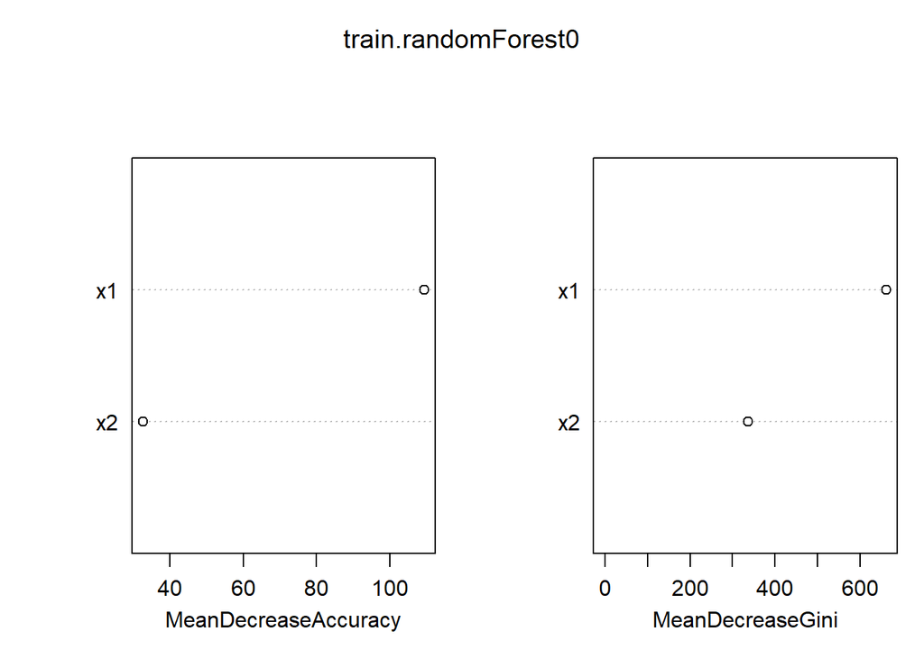

```r
varImpPlot(train.randomForest0 )
```

From the plot of overall OOB training error we can see that n=22 trees is adequate:

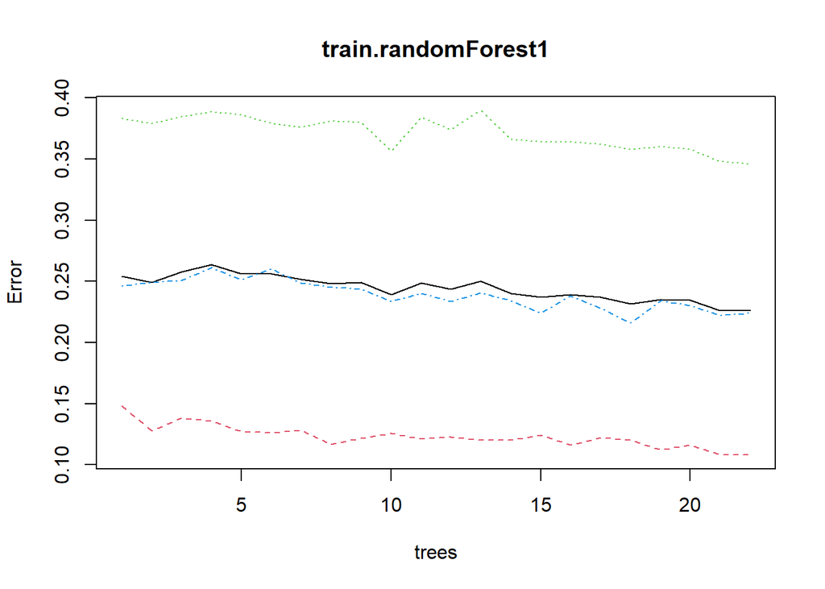

```r
#set seed for reproducibility:
set.seed(1237)
# Create Random forest
train.randomForest1 <- randomForest(y ~ .,
                                    data = train,
                                    ntree = 22,
                                    importance = TRUE)
plot(train.randomForest1)
```

We can now see how well this model predicts the testing data:

```r
pred.test.randomForest1  <- predict(train.randomForest1,
                          newdata = test,
                          type = "class")
confusionMatrix(pred.test.randomForest1, test$y)
```

```
## Confusion Matrix and Statistics
##
##           Reference
## Prediction  1  2  3
##          1 46  5  0
##          2  4 33  6
##          3  0 12 44
##
## Overall Statistics
##
##                Accuracy : 0.82
##                  95% CI : (0.749, 0.8779)
##     No Information Rate : 0.3333
##     P-Value [Acc > NIR] : < 2.2e-16
##
##                   Kappa : 0.73
##
##  Mcnemar's Test P-Value : NA
##
## Statistics by Class:
##
##                      Class: 1 Class: 2 Class: 3
## Sensitivity            0.9200   0.6600   0.8800
## Specificity            0.9500   0.9000   0.8800
## Pos Pred Value         0.9020   0.7674   0.7857
## Neg Pred Value         0.9596   0.8411   0.9362
## Prevalence             0.3333   0.3333   0.3333
## Detection Rate         0.3067   0.2200   0.2933
## Detection Prevalence   0.3400   0.2867   0.3733
## Balanced Accuracy      0.9350   0.7800   0.8800
```

The testing set error rate is $1-0.82=0.18$. It is also interesting to note that, again, no incorrect predictions are between y=1 and y=3.

## Gradient Boosting

```r
#set seed for reproducibility:
set.seed(1237)
#create the bradient boosted model:
train.gbm0 <- gbm(y ~ .,
                  data = train,
                  cv.folds = 5)
```

```
## Distribution not specified, assuming multinomial ...
```

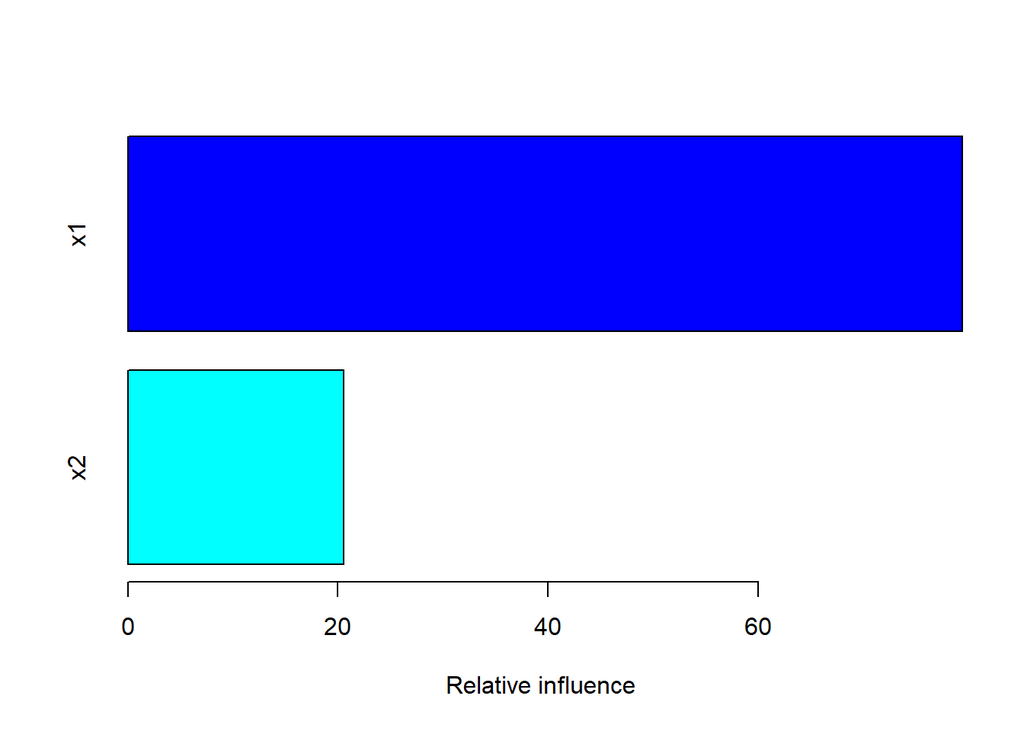

```
##    var  rel.inf
## x1  x1 79.47356
## x2  x2 20.52644
```

```r
#display the results:
summary(train.gbm0)
```

```r
train.gbm0.class <- apply(train.gbm0$fit,1,which.max)
table(train.gbm0.class, train$y)
```

```
##
## train.gbm0.class   1   2   3
##                1 466  52   0
##                2  33 341  52
##                3   1 107 448
```

If we assume that ‘best.iter’ refers to the output of the GBM performance function, as in the sample code, we will check the performance with cross-validation:

```r
best.iter <- gbm.perf(train.gbm0, method = "cv")
```

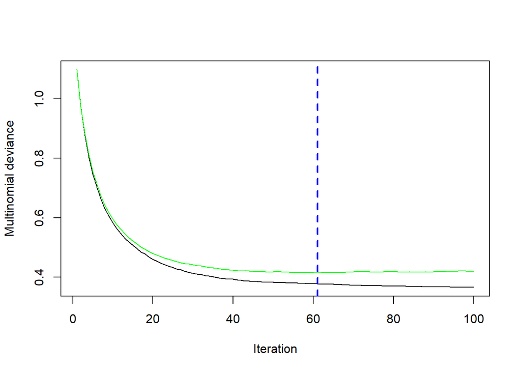

```r
print(best.iter)
```

```
## [1] 61
```

We can see that the best number of iterations is 61; we can now use this to make predictions from the test set:

```r
pred.test.gbm0 <- predict(train.gbm0,
                          newdata = test,
                          n.trees = 61)

#NB type = 'response' is not implemnted for predict.gbm
#So we need to convert to responses as below:
responses.gbm0 <- as.factor(apply(pred.test.gbm0,1,which.max))

#Here's the confsion matrix:
confusionMatrix(responses.gbm0, test$y)
```

```
## Confusion Matrix and Statistics
##
##           Reference
## Prediction  1  2  3
##          1 47  4  0
##          2  3 36  2
##          3  0 10 48
##
## Overall Statistics
##
##                Accuracy : 0.8733
##                  95% CI : (0.8093, 0.922)
##     No Information Rate : 0.3333
##     P-Value [Acc > NIR] : < 2.2e-16
##
##                   Kappa : 0.81
##
##  Mcnemar's Test P-Value : NA
##
## Statistics by Class:
##
##                      Class: 1 Class: 2 Class: 3
## Sensitivity            0.9400   0.7200   0.9600
## Specificity            0.9600   0.9500   0.9000
## Pos Pred Value         0.9216   0.8780   0.8276
## Neg Pred Value         0.9697   0.8716   0.9783
## Prevalence             0.3333   0.3333   0.3333
## Detection Rate         0.3133   0.2400   0.3200
## Detection Prevalence   0.3400   0.2733   0.3867
## Balanced Accuracy      0.9500   0.8350   0.9300
```

## Support Vector Machines

Creating support vector machines with differing costs:

```r
train.svm0 <- svm(y ~ .,
                  data = train,
                  kernel = "radial",  #this is the default value when unspecified
                  cost = 1)           #cost = 1 is the default value when no cost is specified
print(train.svm0)
```

```
##
## Call:
## svm(formula = y ~ ., data = train, kernel = "radial", cost = 1)
##
##
## Parameters:
##    SVM-Type:  C-classification
##  SVM-Kernel:  radial
##        cost:  1
##
## Number of Support Vectors:  635
```

```r
summary(train.svm0)
```

```
##
## Call:
## svm(formula = y ~ ., data = train, kernel = "radial", cost = 1)
##
##
## Parameters:
##    SVM-Type:  C-classification
##  SVM-Kernel:  radial
##        cost:  1
##
## Number of Support Vectors:  635
##
##  ( 116 306 213 )
##
##
## Number of Classes:  3
##
## Levels:
##  1 2 3
```

```r
train.svm5 <- svm(y ~ .,
                  data = train,
                  cost = 5)
print(train.svm5)
```

```
##
## Call:
## svm(formula = y ~ ., data = train, cost = 5)
##
##
## Parameters:
##    SVM-Type:  C-classification
##  SVM-Kernel:  radial
##        cost:  5
##
## Number of Support Vectors:  619
```

```r
summary(train.svm5)
```

```
##
## Call:
## svm(formula = y ~ ., data = train, cost = 5)
##
##
## Parameters:
##    SVM-Type:  C-classification
##  SVM-Kernel:  radial
##        cost:  5
##
## Number of Support Vectors:  619
##
##  ( 113 299 207 )
##
##
## Number of Classes:  3
##
## Levels:
##  1 2 3
```

```r
train.svm10 <- svm(y ~ .,
                  data = train,
                  cost = 10)
print(train.svm10)
```

```
##
## Call:
## svm(formula = y ~ ., data = train, cost = 10)
##
##
## Parameters:
##    SVM-Type:  C-classification
##  SVM-Kernel:  radial
##        cost:  10
##
## Number of Support Vectors:  616
```

```r
summary(train.svm10)
```

```
##
## Call:
## svm(formula = y ~ ., data = train, cost = 10)
##
##
## Parameters:
##    SVM-Type:  C-classification
##  SVM-Kernel:  radial
##        cost:  10
##
## Number of Support Vectors:  616
##
##  ( 112 300 204 )
##
##
## Number of Classes:  3
##
## Levels:
##  1 2 3
```

```r
train.svm50 <- svm(y ~ .,
                  data = train,
                  cost = 50)
print(train.svm50)
```

```
##
## Call:
## svm(formula = y ~ ., data = train, cost = 50)
##
##
## Parameters:
##    SVM-Type:  C-classification
##  SVM-Kernel:  radial
##        cost:  50
##
## Number of Support Vectors:  611
```

```r
summary(train.svm50)
```

```
##
## Call:
## svm(formula = y ~ ., data = train, cost = 50)
##
##
## Parameters:
##    SVM-Type:  C-classification
##  SVM-Kernel:  radial
##        cost:  50
##
## Number of Support Vectors:  611
##
##  ( 109 295 207 )
##
##
## Number of Classes:  3
##
## Levels:
##  1 2 3
```

```r
train.svm100 <- svm(y ~ .,
                  data = train,
                  cost = 100)
print(train.svm100)
```

```
##
## Call:
## svm(formula = y ~ ., data = train, cost = 100)
##
##
## Parameters:
##    SVM-Type:  C-classification
##  SVM-Kernel:  radial
##        cost:  100
##
## Number of Support Vectors:  609
```

```r
summary(train.svm100)
```

```
##
## Call:
## svm(formula = y ~ ., data = train, cost = 100)
##
##
## Parameters:
##    SVM-Type:  C-classification
##  SVM-Kernel:  radial
##        cost:  100
##
## Number of Support Vectors:  609
##
##  ( 109 294 206 )
##
##
## Number of Classes:  3
##
## Levels:
##  1 2 3
```

```r
train.svm1000 <- svm(y ~ .,
                  data = train,
                  cost = 1000)
print(train.svm1000)
```

```
##
## Call:
## svm(formula = y ~ ., data = train, cost = 1000)
##
##
## Parameters:
##    SVM-Type:  C-classification
##  SVM-Kernel:  radial
##        cost:  1000
##
## Number of Support Vectors:  614
```

```r
summary(train.svm1000)
```

```
##
## Call:
## svm(formula = y ~ ., data = train, cost = 1000)
##
##
## Parameters:
##    SVM-Type:  C-classification
##  SVM-Kernel:  radial
##        cost:  1000
##
## Number of Support Vectors:  614
##
##  ( 112 297 205 )
##
##
## Number of Classes:  3
##
## Levels:
##  1 2 3
```

We can now plot the various results of these models:

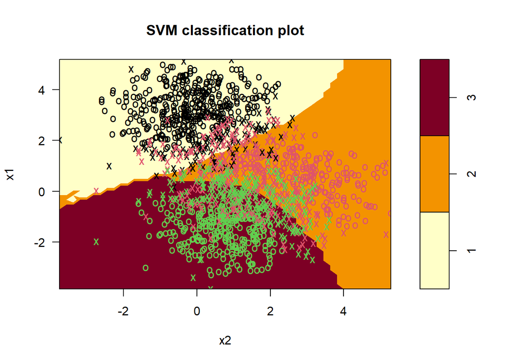

```r
plot(train.svm0,
     main = "SVM classification plot for cost 1",
     data = train)
```

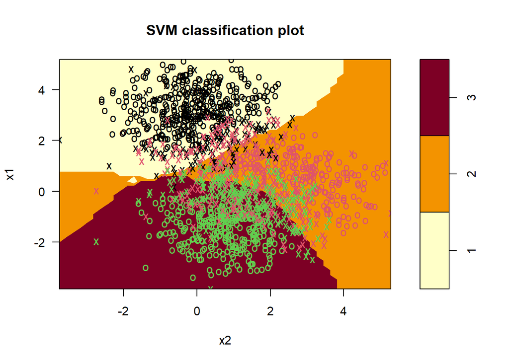

```r
plot(train.svm5,
     main = "SVM classification plot for cost 5",
     data = train)
```

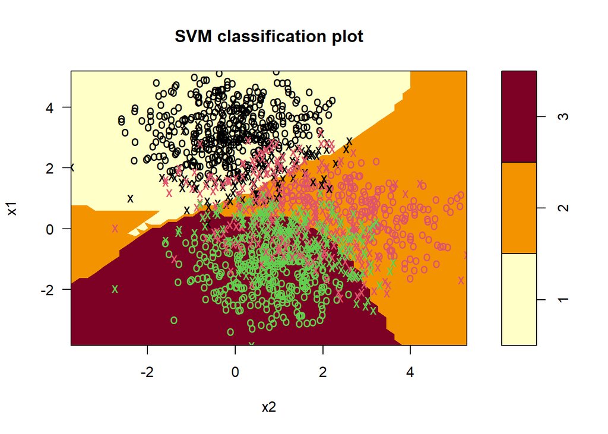

```r
plot(train.svm10,
     main = "SVM classification plot for cost 10",
     data = train)
```

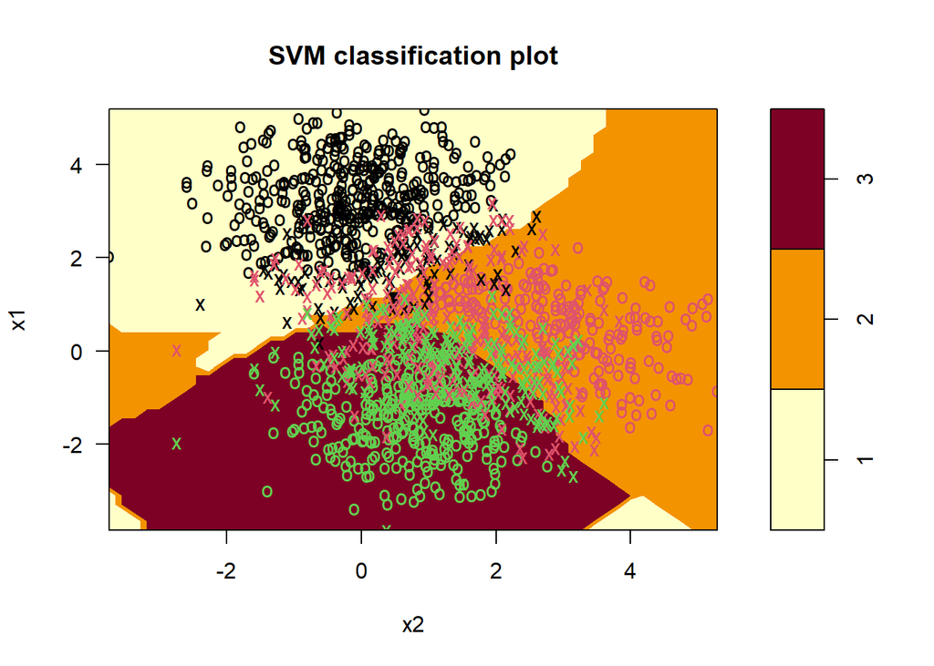

```r
plot(train.svm50,
     main = "SVM classification plot for cost 50",
     data = train)
```

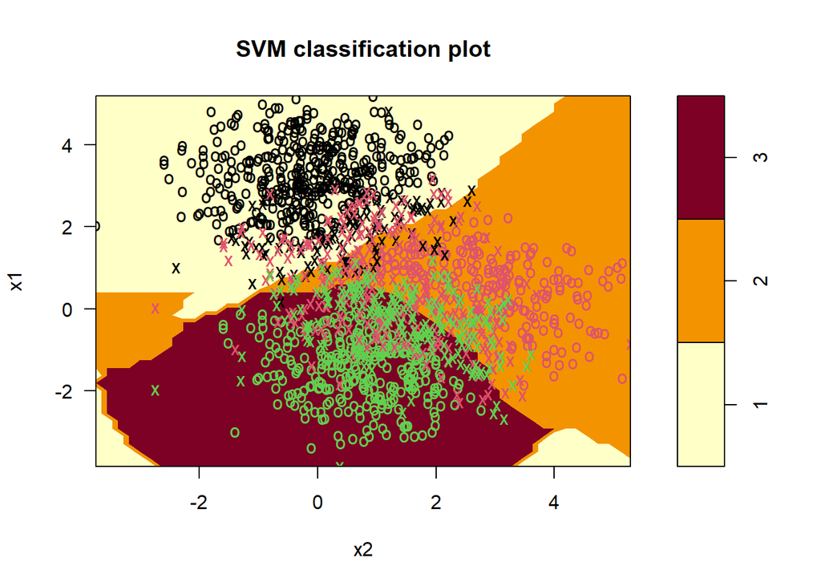

```r
plot(train.svm100,
     main = "SVM classification plot for cost 100",
     data = train)
```

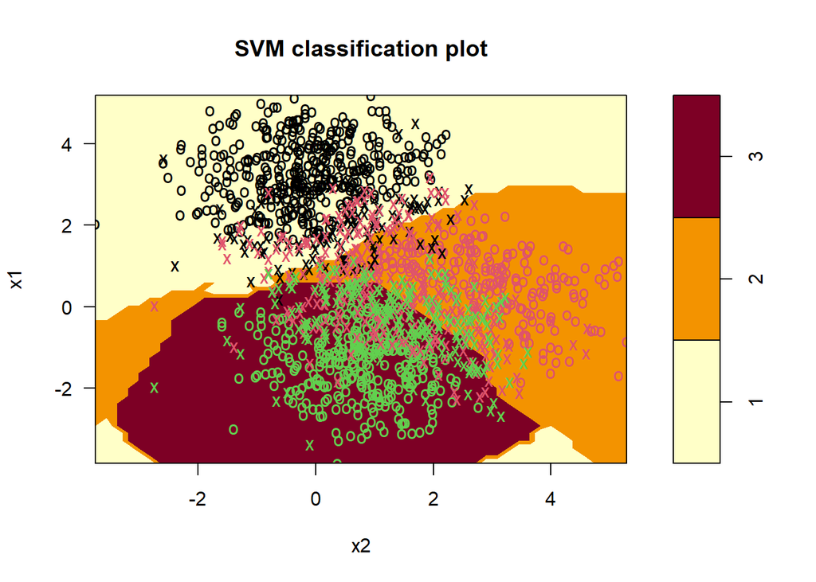

```r
plot(train.svm1000,
     main = "SVM classification plot for cost 1000",
     data = train)
```

We can now make predictions of the test dataset:

```r
pred.test.svm0 <- predict(train.svm0,
                          newdata = test)
pred.test.svm5 <- predict(train.svm5,
                          newdata = test)
pred.test.svm10 <- predict(train.svm10,
                          newdata = test)
pred.test.svm50 <- predict(train.svm50,
                          newdata = test)
pred.test.svm100 <- predict(train.svm100,
                          newdata = test)
pred.test.svm1000 <- predict(train.svm1000,
                          newdata = test)

#Here's the confsion matrix:
confusionMatrix(pred.test.svm0, test$y)
```

```
## Confusion Matrix and Statistics
##
##           Reference
## Prediction  1  2  3
##          1 49  6  0
##          2  1 34  3
##          3  0 10 47
##
## Overall Statistics
##
##                Accuracy : 0.8667
##                  95% CI : (0.8016, 0.9166)
##     No Information Rate : 0.3333
##     P-Value [Acc > NIR] : < 2.2e-16
##
##                   Kappa : 0.8
##
##  Mcnemar's Test P-Value : NA
##
## Statistics by Class:
##
##                      Class: 1 Class: 2 Class: 3
## Sensitivity            0.9800   0.6800   0.9400
## Specificity            0.9400   0.9600   0.9000
## Pos Pred Value         0.8909   0.8947   0.8246
## Neg Pred Value         0.9895   0.8571   0.9677
## Prevalence             0.3333   0.3333   0.3333
## Detection Rate         0.3267   0.2267   0.3133
## Detection Prevalence   0.3667   0.2533   0.3800
## Balanced Accuracy      0.9600   0.8200   0.9200
```

```r
confusionMatrix(pred.test.svm5, test$y)
```

```
## Confusion Matrix and Statistics
##
##           Reference
## Prediction  1  2  3
##          1 49  7  0
##          2  1 30  3
##          3  0 13 47
##
## Overall Statistics
##
##                Accuracy : 0.84
##                  95% CI : (0.7714, 0.8947)
##     No Information Rate : 0.3333
##     P-Value [Acc > NIR] : < 2.2e-16
##
##                   Kappa : 0.76
##
##  Mcnemar's Test P-Value : NA
##
## Statistics by Class:
##
##                      Class: 1 Class: 2 Class: 3
## Sensitivity            0.9800   0.6000   0.9400
## Specificity            0.9300   0.9600   0.8700
## Pos Pred Value         0.8750   0.8824   0.7833
## Neg Pred Value         0.9894   0.8276   0.9667
## Prevalence             0.3333   0.3333   0.3333
## Detection Rate         0.3267   0.2000   0.3133
## Detection Prevalence   0.3733   0.2267   0.4000
## Balanced Accuracy      0.9550   0.7800   0.9050
```

```r
confusionMatrix(pred.test.svm10, test$y)
```

```
## Confusion Matrix and Statistics
##
##           Reference
## Prediction  1  2  3
##          1 50  7  0
##          2  0 30  3
##          3  0 13 47
##
## Overall Statistics
##
##                Accuracy : 0.8467
##                  95% CI : (0.7789, 0.9002)
##     No Information Rate : 0.3333
##     P-Value [Acc > NIR] : < 2.2e-16
##
##                   Kappa : 0.77
##
##  Mcnemar's Test P-Value : NA
##
## Statistics by Class:
##
##                      Class: 1 Class: 2 Class: 3
## Sensitivity            1.0000   0.6000   0.9400
## Specificity            0.9300   0.9700   0.8700
## Pos Pred Value         0.8772   0.9091   0.7833
## Neg Pred Value         1.0000   0.8291   0.9667
## Prevalence             0.3333   0.3333   0.3333
## Detection Rate         0.3333   0.2000   0.3133
## Detection Prevalence   0.3800   0.2200   0.4000
## Balanced Accuracy      0.9650   0.7850   0.9050
```

```r
confusionMatrix(pred.test.svm50, test$y)
```

```
## Confusion Matrix and Statistics
##
##           Reference
## Prediction  1  2  3
##          1 49  7  0
##          2  1 31  3
##          3  0 12 47
##
## Overall Statistics
##
##                Accuracy : 0.8467
##                  95% CI : (0.7789, 0.9002)
##     No Information Rate : 0.3333
##     P-Value [Acc > NIR] : < 2.2e-16
##
##                   Kappa : 0.77
##
##  Mcnemar's Test P-Value : NA
##
## Statistics by Class:
##
##                      Class: 1 Class: 2 Class: 3
## Sensitivity            0.9800   0.6200   0.9400
## Specificity            0.9300   0.9600   0.8800
## Pos Pred Value         0.8750   0.8857   0.7966
## Neg Pred Value         0.9894   0.8348   0.9670
## Prevalence             0.3333   0.3333   0.3333
## Detection Rate         0.3267   0.2067   0.3133
## Detection Prevalence   0.3733   0.2333   0.3933
## Balanced Accuracy      0.9550   0.7900   0.9100
```

```r
confusionMatrix(pred.test.svm100, test$y)
```

```
## Confusion Matrix and Statistics
##
##           Reference
## Prediction  1  2  3
##          1 49  7  0
##          2  1 32  3
##          3  0 11 47
##
## Overall Statistics
##
##                Accuracy : 0.8533
##                  95% CI : (0.7864, 0.9057)
##     No Information Rate : 0.3333
##     P-Value [Acc > NIR] : < 2.2e-16
##
##                   Kappa : 0.78
##
##  Mcnemar's Test P-Value : NA
##
## Statistics by Class:
##
##                      Class: 1 Class: 2 Class: 3
## Sensitivity            0.9800   0.6400   0.9400
## Specificity            0.9300   0.9600   0.8900
## Pos Pred Value         0.8750   0.8889   0.8103
## Neg Pred Value         0.9894   0.8421   0.9674
## Prevalence             0.3333   0.3333   0.3333
## Detection Rate         0.3267   0.2133   0.3133
## Detection Prevalence   0.3733   0.2400   0.3867
## Balanced Accuracy      0.9550   0.8000   0.9150
```

```r
confusionMatrix(pred.test.svm1000, test$y)
```

```
## Confusion Matrix and Statistics
##
##           Reference
## Prediction  1  2  3
##          1 49  6  0
##          2  1 32  2
##          3  0 12 48
##
## Overall Statistics
##
##                Accuracy : 0.86
##                  95% CI : (0.794, 0.9112)
##     No Information Rate : 0.3333
##     P-Value [Acc > NIR] : < 2.2e-16
##
##                   Kappa : 0.79
##
##  Mcnemar's Test P-Value : NA
##
## Statistics by Class:
##
##                      Class: 1 Class: 2 Class: 3
## Sensitivity            0.9800   0.6400   0.9600
## Specificity            0.9400   0.9700   0.8800
## Pos Pred Value         0.8909   0.9143   0.8000
## Neg Pred Value         0.9895   0.8435   0.9778
## Prevalence             0.3333   0.3333   0.3333
## Detection Rate         0.3267   0.2133   0.3200
## Detection Prevalence   0.3667   0.2333   0.4000
## Balanced Accuracy      0.9600   0.8050   0.9200
```

Interestingly, we can see that cost = 1 produces the best accuracy.

## Multicategory SVM Pathing

```r
# For reproducibility
set.seed(1237)

#We need to create a new matrix for the x-variable in the msvmpath function:
x.train = train[,-1]
y.train = train[,1]
x.train = as.matrix(x.train)
y.train = as.numeric(as.factor(y.train))

x.test = test[,-1]
y.test = test[,1]
x.test = as.matrix(x.test)
y.test = as.numeric(as.factor(y.test))

train.msvmpath0 <- msvmpath(x = x.train,
                            y = y.train,
                            fract = 0.5,             #sets fraction used tor solution path to half
                            tune.rest = TRUE,        #the other half are used for tuning lambda value
                            kernel.function = radial.kernel)
#Just junk code below:

# pred.test.msvmpath0 <- predict.msvmpath(train.msvmpath0,
#                                         x.test,
#                                         train.msvmpath0$opt.lambda,
#                                         type = "class")
#
# summary.msvmpath(train.msvmpath0)


# irispath=msvmpath(x.1, y.1, fract=0.5,tune.rest=TRUE,kernel.function=radial.kernel)
# irispath.pred = predict.msvmpath(irispath,x.2,irispath$opt.lambda,type="class")
# summary.msvmpath(irispath)
# #print(irispath)
# test.error.rate=mean(irispath.pred!=y.2)
# test.error.rate
```

```r
pred.test.msvmpath0 <- predict.msvmpath(train.msvmpath0,
                                        newx = x.test,
                                        lambda = train.msvmpath0$opt.lambda,
                                        type = "class")
summary.msvmpath(train.msvmpath0)
```

```
##
## Call:
## msvmpath(x = x.train, y = y.train, kernel.function = radial.kernel,
##     fract = 0.5, tune.rest = TRUE)
##
## Number of steps: 32
## Selected steps:
```

```
##      Lambda     Error Size.Elbow Support      Loss
## 1  0.352410 0.2613333          3    1500 0.3111368
## 5  0.349855 0.2613333          3    1499 0.3106909
## 10 0.346028 0.2626667          2    1496 0.3100111
## 15 0.343747 0.2626667          3    1495 0.3094589
## 20 0.341582 0.2626667          4    1493 0.3089708
## 25 0.338573 0.2626667          3    1491 0.3082367
## 30 0.337439 0.2626667          4    1490 0.3080709
## 32 0.336022 0.2626667          4    1488 0.3077455
```

```r
#Here's the confusion matrix:
confusionMatrix(as.factor(pred.test.msvmpath0), test$y)
```

```
## Confusion Matrix and Statistics
##
##           Reference
## Prediction  1  2  3
##          1 50 12  0
##          2  0 16  0
##          3  0 22 50
##
## Overall Statistics
##
##                Accuracy : 0.7733
##                  95% CI : (0.6979, 0.8376)
##     No Information Rate : 0.3333
##     P-Value [Acc > NIR] : < 2.2e-16
##
##                   Kappa : 0.66
##
##  Mcnemar's Test P-Value : NA
##
## Statistics by Class:
##
##                      Class: 1 Class: 2 Class: 3
## Sensitivity            1.0000   0.3200   1.0000
## Specificity            0.8800   1.0000   0.7800
## Pos Pred Value         0.8065   1.0000   0.6944
## Neg Pred Value         1.0000   0.7463   1.0000
## Prevalence             0.3333   0.3333   0.3333
## Detection Rate         0.3333   0.1067   0.3333
## Detection Prevalence   0.4133   0.1067   0.4800
## Balanced Accuracy      0.9400   0.6600   0.8900
```

Interestingly, the accuracy is very poor here. Perhaps something went wrong?

## Conclusion

Unsurprisingly, the gradient boosting algorithm had the best overall accuracy of 87.33%.

# References

1. Efron B. Prediction, Estimation, and Attribution. Journal of the American Statistical Association. 2020;115(530):636-655. doi:10.1080/01621459.2020.1762613
2. James G, Witten D, Hastie T, Tibshirani R. An Introduction to Statistical Learning: With Applications in R. 1st ed. 2013, Corr. 7th printing 2017 edition. Springer; 2013.